# ISDS Mid-term Exam

Tyler McDonald

September 26, 2018

## Data Inspection

There are a total of 28 departments in this dataset.

```
## # A tibble: 28 x 2
## # Groups:   department_name [28]
##    department_name                    n
##    <chr>                          <int>
##  1 POLICE DEPARTMENT                196
##  2 LIBRARY BOARD OF CONTROL         151
##  3 FIRE DEPARTMENT                   97
##  4 HUMAN DEVELOPMENT AND SERVICES    65
##  5 EMERGENCY MEDICAL SERVICES        63
##  6 DEPARTMENT OF PUBLIC WORKS        55
##  7 DEPT OF MAINTENANCE               52
##  8 FINANCE DEPARTMENT                34
##  9 OFFICE OF THE MAYOR-PRESIDENT     33
## 10 CITY COURT                        32
## # ... with 18 more rows
```

The departments in order of number of employees are as follows: POLICE DEPARTMENT, LIBRARY BOARD OF CONTROL, FIRE DEPARTMENT, HUMAN DEVELOPMENT AND SERVICES, EMERGENCY MEDICAL SERVICES, DEPARTMENT OF PUBLIC WORKS, DEPT OF MAINTENANCE, FINANCE DEPARTMENT, OFFICE OF THE MAYOR-PRESIDENT, CITY COURT, PARISH ATTORNEY, DEPT OF TRANSPORTATION AND DRAINAGE, GREATER BATON ROUGE AIRPORT DISTRICT, DEPT OF DEVELOPMENT, JUVENILE SERVICES, DEPT OF FLEET MANAGEMENT, METROPOLITAN COUNCIL, DEPT OF BUILDINGS AND GROUNDS, INFORMATION SERVICES, DEPT OF BUSINESS OPERATIONS AND CAPITAL PROGRAMS, HUMAN RESOURCES, PLANNING COMMISSION, ANIMAL CONTROL CENTER, COMMUNITY DEVELOPMENT PROGRAMS, MOSQUITO & RODENT CONTROL, CITY CONSTABLE, COUNCIL ADMINISTRATOR, PURCHASING. The total number of observations in MOSQUITO & RODENT CONTROL IS 8.

## Data Preparation

```
## # A tibble: 22 x 5
## # Groups:   department_name [22]
##    department_name                retirement     n total percent
##    <chr>                          <lgl>      <int> <int>   <dbl>
##  1 OFFICE OF THE MAYOR-PRESIDENT  TRUE          28    33  0.848
##  2 LIBRARY BOARD OF CONTROL       TRUE          25   151  0.166
##  3 DEPT OF MAINTENANCE            TRUE          21    52  0.404
##  4 POLICE DEPARTMENT              TRUE          14   196  0.0714
##  5 HUMAN DEVELOPMENT AND SERVICES TRUE          13    65  0.2
##  6 CITY COURT                     TRUE           9    32  0.281
##  7 EMERGENCY MEDICAL SERVICES     TRUE           9    63  0.143
##  8 DEPARTMENT OF PUBLIC WORKS     TRUE           7    55  0.127
##  9 PARISH ATTORNEY                TRUE           5    28  0.179
## 10 FINANCE DEPARTMENT             TRUE           4    34  0.118
## # ... with 12 more rows
```

```
## # A tibble: 2 x 2
##   retirement total
##   <lgl>      <int>
## 1 FALSE        838
## 2 TRUE         157
```

A total of 157 people retired while 838 did not.

## Data Visualization

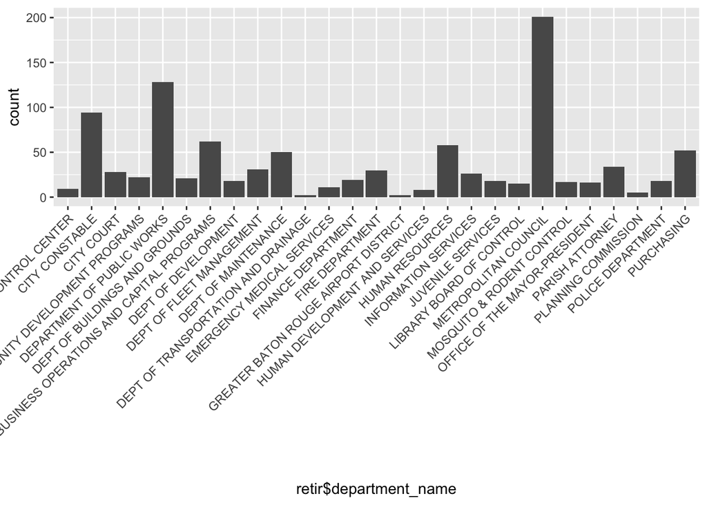

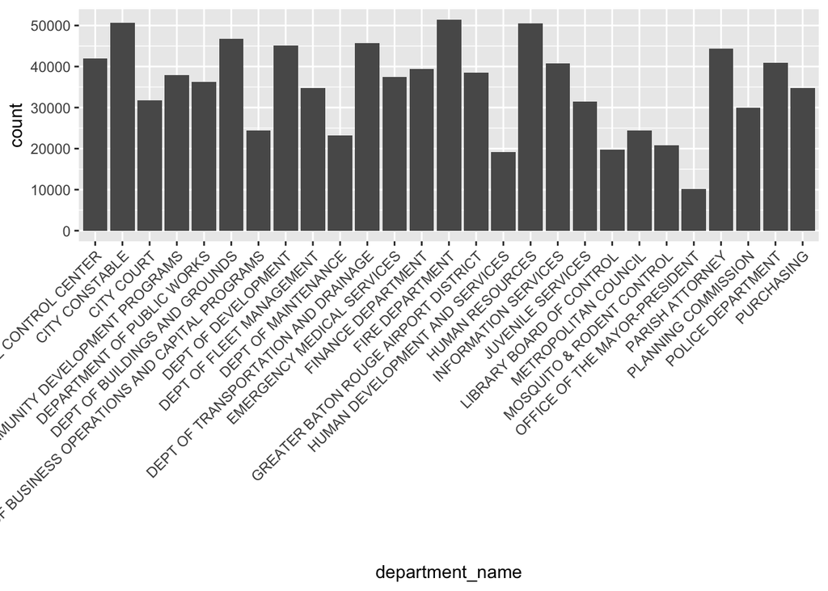

```
## # A tibble: 27 x 2
##    department_name                                  average
##    <chr>                                              <dbl>
##  1 ANIMAL CONTROL CENTER                             41896.
##  2 CITY CONSTABLE                                    50590.
##  3 CITY COURT                                        31718.
##  4 COMMUNITY DEVELOPMENT PROGRAMS                    37930.
##  5 DEPARTMENT OF PUBLIC WORKS                        36256.
##  6 DEPT OF BUILDINGS AND GROUNDS                     46766.
##  7 DEPT OF BUSINESS OPERATIONS AND CAPITAL PROGRAMS  24385.
##  8 DEPT OF DEVELOPMENT                               45185.
##  9 DEPT OF FLEET MANAGEMENT                          34736.
## 10 DEPT OF MAINTENANCE                               23283.
## # ... with 17 more rows
```

```
## # A tibble: 10 x 2
##    department_name                     average
##    <chr>                                 <dbl>
##  1 FIRE DEPARTMENT                      51448.
##  2 CITY CONSTABLE                       50590.
##  3 HUMAN RESOURCES                      50529.
##  4 DEPT OF BUILDINGS AND GROUNDS        46766.
##  5 DEPT OF TRANSPORTATION AND DRAINAGE  45767.
##  6 DEPT OF DEVELOPMENT                  45185.
##  7 PARISH ATTORNEY                      44409.
##  8 ANIMAL CONTROL CENTER                41896.
##  9 POLICE DEPARTMENT                    40952.
## 10 INFORMATION SERVICES                 40744.
```

```
## # A tibble: 3 x 2
##   department_name            average
##   <chr>                        <dbl>
## 1 POLICE DEPARTMENT            9566.
## 2 EMERGENCY MEDICAL SERVICES   8478.
## 3 DEPARTMENT OF PUBLIC WORKS   8108.
```